# Exploration of Loan Data from Prosper

## Preliminary Wrangling

> This data set contains 113,937 loans with 81 variables on each loan, including loan amount, borrower rate (or interest rate), current loan status, borrower income, and many others.

```python
# import all packages and set plots to be embedded inline
import numpy as np
import pandas as pd
import matplotlib.pyplot as plt
import seaborn as sb

%matplotlib inline
```

```python
data = pd.read_csv('prosperLoanData.csv')
```

```python
# We make a copy of our dataset on which we will be making all our changes without affecting the original dataset
df = data.copy()
```

## Assessing and Cleaning the dataset

### Assessing

```python
df.head()
```

|  | ListingKey | ListingNumber | ListingCreationDate | CreditGrade | Term | LoanStatus | ClosedDate | BorrowerAPR | BorrowerRate | LenderYield | ... | LP_ServiceFees | LP_CollectionFees | LP_GrossPrincipalLoss | LP_NetPrincipalLoss | LP_NonPrincipalRecoverypayments | PercentFunded | Recommendations | InvestmentFromFriendsCount | InvestmentFromFriendsAmount | Investors |
| --- | --- | --- | --- | --- | --- | --- | --- | --- | --- | --- | --- | --- | --- | --- | --- | --- | --- | --- | --- | --- | --- |
| 0 | 1021339766868145413AB3B | 193129 | 2007-08-26 19:09:29.263000000 | C | 36 | Completed | 2009-08-14 00:00:00 | 0.16516 | 0.1580 | 0.1380 | ... | -133.18 | 0.0 | 0.0 | 0.0 | 0.0 | 1.0 | 0 | 0 | 0.0 | 258 |
| 1 | 10273602499503308B223C1 | 1209647 | 2014-02-27 08:28:07.900000000 | NaN | 36 | Current | NaN | 0.12016 | 0.0920 | 0.0820 | ... | 0.00 | 0.0 | 0.0 | 0.0 | 0.0 | 1.0 | 0 | 0 | 0.0 | 1 |
| 2 | 0EE9337825851032864889A | 81716 | 2007-01-05 15:00:47.090000000 | HR | 36 | Completed | 2009-12-17 00:00:00 | 0.28269 | 0.2750 | 0.2400 | ... | -24.20 | 0.0 | 0.0 | 0.0 | 0.0 | 1.0 | 0 | 0 | 0.0 | 41 |
| 3 | 0EF5356002482715299901A | 658116 | 2012-10-22 11:02:35.010000000 | NaN | 36 | Current | NaN | 0.12528 | 0.0974 | 0.0874 | ... | -108.01 | 0.0 | 0.0 | 0.0 | 0.0 | 1.0 | 0 | 0 | 0.0 | 158 |
| 4 | 0F023589499656230C5E3E2 | 909464 | 2013-09-14 18:38:39.097000000 | NaN | 36 | Current | NaN | 0.24614 | 0.2085 | 0.1985 | ... | -60.27 | 0.0 | 0.0 | 0.0 | 0.0 | 1.0 | 0 | 0 | 0.0 | 20 |

5 rows × 81 columns

```python
df.info()
```

```
<class 'pandas.core.frame.DataFrame'>
RangeIndex: 113937 entries, 0 to 113936
Data columns (total 81 columns):
ListingKey                             113937 non-null object
ListingNumber                          113937 non-null int64
ListingCreationDate                    113937 non-null object
CreditGrade                            28953 non-null object
Term                                   113937 non-null int64
LoanStatus                             113937 non-null object
ClosedDate                             55089 non-null object
BorrowerAPR                            113912 non-null float64
BorrowerRate                           113937 non-null float64
LenderYield                            113937 non-null float64
EstimatedEffectiveYield                84853 non-null float64
EstimatedLoss                          84853 non-null float64
EstimatedReturn                        84853 non-null float64
ProsperRating (numeric)                84853 non-null float64
ProsperRating (Alpha)                  84853 non-null object
ProsperScore                           84853 non-null float64
ListingCategory (numeric)              113937 non-null int64
BorrowerState                          108422 non-null object
Occupation                             110349 non-null object
EmploymentStatus                       111682 non-null object
EmploymentStatusDuration               106312 non-null float64
IsBorrowerHomeowner                    113937 non-null bool
CurrentlyInGroup                       113937 non-null bool
GroupKey                               13341 non-null object
DateCreditPulled                       113937 non-null object
CreditScoreRangeLower                  113346 non-null float64
CreditScoreRangeUpper                  113346 non-null float64
FirstRecordedCreditLine                113240 non-null object
CurrentCreditLines                     106333 non-null float64
OpenCreditLines                        106333 non-null float64
TotalCreditLinespast7years             113240 non-null float64
OpenRevolvingAccounts                  113937 non-null int64
OpenRevolvingMonthlyPayment            113937 non-null float64
InquiriesLast6Months                   113240 non-null float64
TotalInquiries                         112778 non-null float64
CurrentDelinquencies                   113240 non-null float64
AmountDelinquent                       106315 non-null float64
```

[output cut: 31 more lines]

```
LP_CustomerPayments                    113937 non-null float64
LP_CustomerPrincipalPayments           113937 non-null float64
LP_InterestandFees                     113937 non-null float64
LP_ServiceFees                         113937 non-null float64
LP_CollectionFees                      113937 non-null float64
LP_GrossPrincipalLoss                  113937 non-null float64
LP_NetPrincipalLoss                    113937 non-null float64
LP_NonPrincipalRecoverypayments        113937 non-null float64
PercentFunded                          113937 non-null float64
Recommendations                        113937 non-null int64
InvestmentFromFriendsCount             113937 non-null int64
InvestmentFromFriendsAmount            113937 non-null float64
Investors                              113937 non-null int64
dtypes: bool(3), float64(50), int64(11), object(17)
memory usage: 68.1+ MB
```

## Cleaning

I drop all the columns that I would not be using.

```python
df.drop(columns=['ListingKey','ListingNumber', 'ListingCreationDate', 'ListingCategory (numeric)',
                'DateCreditPulled', 'LoanKey', 'CurrentlyInGroup', 'LoanNumber', 'LoanOriginationDate',
                'LoanOriginationQuarter', 'MemberKey', 'LP_CustomerPayments',
                'LP_CustomerPrincipalPayments','LP_InterestandFees','LP_GrossPrincipalLoss',
                'LP_NetPrincipalLoss', 'LP_NonPrincipalRecoverypayments', 'LP_ServiceFees',
                 'OpenRevolvingAccounts', 'OpenRevolvingMonthlyPayment',
                'IncomeRange', 'LoanMonthsSinceOrigination', 'LenderYield'], inplace=True)
```

```python
df.info()
```

```
<class 'pandas.core.frame.DataFrame'>
RangeIndex: 113937 entries, 0 to 113936
Data columns (total 58 columns):
CreditGrade                            28953 non-null object
Term                                   113937 non-null int64
LoanStatus                             113937 non-null object
ClosedDate                             55089 non-null object
BorrowerAPR                            113912 non-null float64
BorrowerRate                           113937 non-null float64
EstimatedEffectiveYield                84853 non-null float64
EstimatedLoss                          84853 non-null float64
EstimatedReturn                        84853 non-null float64
ProsperRating (numeric)                84853 non-null float64
ProsperRating (Alpha)                  84853 non-null object
ProsperScore                           84853 non-null float64
BorrowerState                          108422 non-null object
Occupation                             110349 non-null object
EmploymentStatus                       111682 non-null object
EmploymentStatusDuration               106312 non-null float64
IsBorrowerHomeowner                    113937 non-null bool
GroupKey                               13341 non-null object
CreditScoreRangeLower                  113346 non-null float64
CreditScoreRangeUpper                  113346 non-null float64
FirstRecordedCreditLine                113240 non-null object
CurrentCreditLines                     106333 non-null float64
OpenCreditLines                        106333 non-null float64
TotalCreditLinespast7years             113240 non-null float64
InquiriesLast6Months                   113240 non-null float64
TotalInquiries                         112778 non-null float64
CurrentDelinquencies                   113240 non-null float64
AmountDelinquent                       106315 non-null float64
DelinquenciesLast7Years                112947 non-null float64
PublicRecordsLast10Years               113240 non-null float64
PublicRecordsLast12Months              106333 non-null float64
RevolvingCreditBalance                 106333 non-null float64
BankcardUtilization                    106333 non-null float64
AvailableBankcardCredit                106393 non-null float64
TotalTrades                            106393 non-null float64
TradesNeverDelinquent (percentage)     106393 non-null float64
TradesOpenedLast6Months                106393 non-null float64
```

[output cut: 8 more lines]

```
ProsperPrincipalBorrowed               22085 non-null float64
ProsperPrincipalOutstanding            22085 non-null float64
ScorexChangeAtTimeOfListing            18928 non-null float64
LoanCurrentDaysDelinquent              113937 non-null int64
LoanFirstDefaultedCycleNumber          16952 non-null float64
LoanOriginalAmount                     113937 non-null int64
MonthlyLoanPayment                     113937 non-null float64
LP_CollectionFees                      113937 non-null float64
PercentFunded                          113937 non-null float64
Recommendations                        113937 non-null int64
InvestmentFromFriendsCount             113937 non-null int64
InvestmentFromFriendsAmount            113937 non-null float64
Investors                              113937 non-null int64
dtypes: bool(2), float64(41), int64(6), object(9)
memory usage: 48.9+ MB
```

### Quality issues

We can already notice missing data in the dataset

### Define

There are some columns where too much data missing, I will start by dropping them first.

### Code

```python
df.drop(columns=['CreditGrade','ClosedDate','BorrowerAPR', 'EstimatedEffectiveYield',
                'EstimatedLoss','EstimatedReturn','ProsperRating (numeric)',
                'ProsperRating (Alpha)','ProsperScore','EmploymentStatusDuration',
                'FirstRecordedCreditLine','CurrentCreditLines',
                'OpenCreditLines','InquiriesLast6Months','TotalInquiries',
                'AmountDelinquent','PublicRecordsLast10Years','PublicRecordsLast12Months',
                'RevolvingCreditBalance','BankcardUtilization','TotalTrades','TradesNeverDelinquent (percentage)',
                'TradesOpenedLast6Months','TotalProsperLoans','TotalProsperPaymentsBilled','OnTimeProsperPayments',
                'ProsperPaymentsLessThanOneMonthLate','ProsperPrincipalBorrowed','ProsperPrincipalOutstanding',
                'ScorexChangeAtTimeOfListing','LoanCurrentDaysDelinquent','LoanFirstDefaultedCycleNumber','PercentFunded',
                'InvestmentFromFriendsAmount','Investors','GroupKey','ProsperPaymentsOneMonthPlusLate',
                'AvailableBankcardCredit'], inplace=True)
```

### Test

```python
df.info()
```

```
<class 'pandas.core.frame.DataFrame'>
RangeIndex: 113937 entries, 0 to 113936
Data columns (total 20 columns):
Term                          113937 non-null int64
LoanStatus                    113937 non-null object
BorrowerRate                  113937 non-null float64
BorrowerState                 108422 non-null object
Occupation                    110349 non-null object
EmploymentStatus              111682 non-null object
IsBorrowerHomeowner           113937 non-null bool
CreditScoreRangeLower         113346 non-null float64
CreditScoreRangeUpper         113346 non-null float64
TotalCreditLinespast7years    113240 non-null float64
CurrentDelinquencies          113240 non-null float64
DelinquenciesLast7Years       112947 non-null float64
DebtToIncomeRatio             105383 non-null float64
IncomeVerifiable              113937 non-null bool
StatedMonthlyIncome           113937 non-null float64
LoanOriginalAmount            113937 non-null int64
MonthlyLoanPayment            113937 non-null float64
LP_CollectionFees             113937 non-null float64
Recommendations               113937 non-null int64
InvestmentFromFriendsCount    113937 non-null int64
dtypes: bool(2), float64(10), int64(4), object(4)
memory usage: 15.9+ MB
```

### Define

We will drop all the rows where DelinquenciesLast7Years is missing.

### Code

```python
DelinquenciesLast7Years_isna_list = list(df[df.DelinquenciesLast7Years.isna()].index)
df.drop(axis=0, index=DelinquenciesLast7Years_isna_list, inplace=True)
```

### Test

```python
df.info()
```

```
<class 'pandas.core.frame.DataFrame'>
Int64Index: 112947 entries, 0 to 113936
Data columns (total 20 columns):
Term                          112947 non-null int64
LoanStatus                    112947 non-null object
BorrowerRate                  112947 non-null float64
BorrowerState                 108202 non-null object
Occupation                    110261 non-null object
EmploymentStatus              111594 non-null object
IsBorrowerHomeowner           112947 non-null bool
CreditScoreRangeLower         112947 non-null float64
CreditScoreRangeUpper         112947 non-null float64
TotalCreditLinespast7years    112947 non-null float64
CurrentDelinquencies          112947 non-null float64
DelinquenciesLast7Years       112947 non-null float64
DebtToIncomeRatio             104505 non-null float64
IncomeVerifiable              112947 non-null bool
StatedMonthlyIncome           112947 non-null float64
LoanOriginalAmount            112947 non-null int64
MonthlyLoanPayment            112947 non-null float64
LP_CollectionFees             112947 non-null float64
Recommendations               112947 non-null int64
InvestmentFromFriendsCount    112947 non-null int64
dtypes: bool(2), float64(10), int64(4), object(4)
memory usage: 16.6+ MB
```

### Define

We have to handle the missing data existing in some of the outstanding data.

### Code

```python
# List of NaN values in the BorrowerState Column
BorrowerState_isna_list = list(df[df.BorrowerState.isna()].index)
# Replacing those values by the string 'Missing'
for i in BorrowerState_isna_list:
    df.at[i, 'BorrowerState'] = 'Missing'
```

```python
# List of NaN values in the Occupation Column
Occupation_isna_list = list(df[df.Occupation.isna()].index)
# Replacing those values by the string 'Missing'
for i in Occupation_isna_list:
    df.at[i, 'Occupation'] = 'Missing'
```

```python
# List of NaN values in the EmploymentStatus Column
EmploymentStatus_isna_list = list(df[df.EmploymentStatus.isna()].index)
# Replacing those values by the string 'Missing'
for i in EmploymentStatus_isna_list:
    df.at[i, 'EmploymentStatus'] = 'Missing'
```

```python
# We will drop the column with missing credit score data
CreditScoreMissing = list(df[df.CreditScoreRangeLower.isna()].index)
df.drop(axis=0, index=CreditScoreMissing, inplace=True)
df.info()
```

```
<class 'pandas.core.frame.DataFrame'>
Int64Index: 112947 entries, 0 to 113936
Data columns (total 20 columns):
Term                          112947 non-null int64
LoanStatus                    112947 non-null object
BorrowerRate                  112947 non-null float64
BorrowerState                 112947 non-null object
Occupation                    112947 non-null object
EmploymentStatus              112947 non-null object
IsBorrowerHomeowner           112947 non-null bool
CreditScoreRangeLower         112947 non-null float64
CreditScoreRangeUpper         112947 non-null float64
TotalCreditLinespast7years    112947 non-null float64
CurrentDelinquencies          112947 non-null float64
DelinquenciesLast7Years       112947 non-null float64
DebtToIncomeRatio             104505 non-null float64
IncomeVerifiable              112947 non-null bool
StatedMonthlyIncome           112947 non-null float64
LoanOriginalAmount            112947 non-null int64
MonthlyLoanPayment            112947 non-null float64
LP_CollectionFees             112947 non-null float64
Recommendations               112947 non-null int64
InvestmentFromFriendsCount    112947 non-null int64
dtypes: bool(2), float64(10), int64(4), object(4)
memory usage: 16.6+ MB
```

### Test

```python
# Is there any remaining columns with missing data?
[col for col in df.columns if df[col].isna().any()]
```

```
['DebtToIncomeRatio']
```

### Define

We will drop the rows for the outstanding missing values on DebtToIncomeRatio

### Code

```python
DebtToIncomeRatio_isna_list = list(df[df.DebtToIncomeRatio.isna()].index)
df.drop(axis=0, index=DebtToIncomeRatio_isna_list, inplace=True)
```

### Test

```python
len([col for col in df.columns if df[col].isna().any()])
```

```
0
```

```python
df.info()
```

```
<class 'pandas.core.frame.DataFrame'>
Int64Index: 104505 entries, 0 to 113936
Data columns (total 20 columns):
Term                          104505 non-null int64
LoanStatus                    104505 non-null object
BorrowerRate                  104505 non-null float64
BorrowerState                 104505 non-null object
Occupation                    104505 non-null object
EmploymentStatus              104505 non-null object
IsBorrowerHomeowner           104505 non-null bool
CreditScoreRangeLower         104505 non-null float64
CreditScoreRangeUpper         104505 non-null float64
TotalCreditLinespast7years    104505 non-null float64
CurrentDelinquencies          104505 non-null float64
DelinquenciesLast7Years       104505 non-null float64
DebtToIncomeRatio             104505 non-null float64
IncomeVerifiable              104505 non-null bool
StatedMonthlyIncome           104505 non-null float64
LoanOriginalAmount            104505 non-null int64
MonthlyLoanPayment            104505 non-null float64
LP_CollectionFees             104505 non-null float64
Recommendations               104505 non-null int64
InvestmentFromFriendsCount    104505 non-null int64
dtypes: bool(2), float64(10), int64(4), object(4)
memory usage: 15.3+ MB
```

### Our data structure

> Our final dataset is composed of 104505 rows and 20 columns, there is no missing values and most of the columns provide informations about lenders financial situation and profile at the moment of the data recording.

### Main feature of interest

> The main feature of interest in the dataset is **LP_CollectionFees**, it represents how much it costs **Prosper Loan** to collect payments from borrowers. Higher is the collection fees, lower is the account value in termn of profitability to the company. Therefore, we will look at what are the characteristics of a bad borrower i.e. a borrower that is less/not profitable for the company.

### Features supporting our investigation

> It is not clear yet what may be all the features that could help support our investigation. We start be using common sense and intuition to explore a set features and eventually add some more if necessary. So, the features we will be starting with are the following: **'EmploymentStatus'**, **'Occupation'**, **'BorrowerState'**, **'CreditScore'**, **'DebtToIncomeRatio'**, because we are hypothesizing that those variables could be determinant on the ability of an applicant to qualify for a loan, get a competitive rate and be able to repay it back properly. CreditScore is not a feature that currently exist in our dataset, however we will be able to explore it by creating a new variable of the same name that will be equal to the average of CreditScoreRangeLower and CreditScoreRangeUpper. Before going any further, let's create it.

```python
df['CreditScore'] = (df['CreditScoreRangeLower'] + df['CreditScoreRangeUpper'])/2
```

## Univariate Exploration

### LP_CollectionFees

```python
df.LP_CollectionFees.describe()
```

```
count    104505.000000
mean        -14.160578
std         109.245206
min       -9274.750000
25%           0.000000
50%           0.000000
75%           0.000000
max           0.000000
Name: LP_CollectionFees, dtype: float64
```

We will subset the dataset to one including only the population of interest for this study, which is those who have a **LP_CollectionFees** lower than 0. We will call it **df1**.

```python
df1 = df[df.LP_CollectionFees < 0]
```

```python
# Save the newly created dataset in a csv file in the same directory as this notebook
df1.to_csv('df1.csv')
```

### Occupation

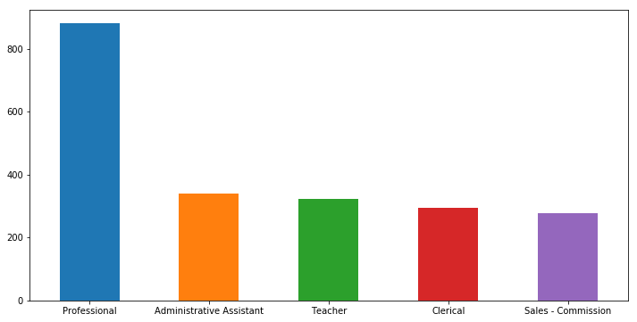

```python
# Most highest Occupations by count
df1['Occupation'][df1.Occupation != 'Other'].value_counts()[:5].plot(kind='bar', figsize=(12,6));
plt.xticks(rotation=0);
```

### EmploymentStatus

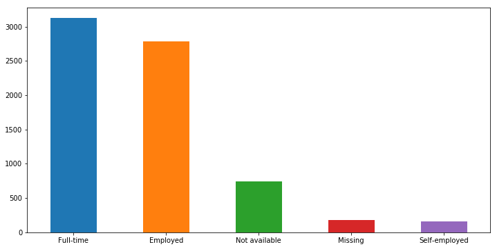

```python
# Most highest Employment Status by count
df1.EmploymentStatus.value_counts()[:5].plot(kind='bar', figsize=(12,6));
plt.xticks(rotation=0);
```

The majority of those borrowers are either working **Full-time** or are **Employed**.

### BorrowerState

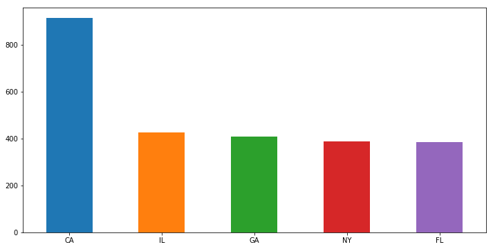

```python
# 5 most important Borrowers States
df1.query("BorrowerState != 'Missing'")['BorrowerState'].value_counts()[:5].plot(kind='bar', figsize=(12,6));
plt.xticks(rotation=0);
```

**California** is the state with the highest number of observation

### CreditScore

A credit score of 700 and above is considered a good one.

```python
df1.CreditScore.describe()
```

```
count    7394.000000
mean      658.723695
std        75.050228
min         9.500000
25%       629.500000
50%       669.500000
75%       709.500000
max       869.500000
Name: CreditScore, dtype: float64
```

```python
# What are the outliers boundaries?
q1, q3= np.percentile(df1.CreditScore,[25,75])
iqr = q3 - q1
lower_bound = q1 - (1.5 * q1)
upper_bound = q3 + (1.5 * q3)
print("Outlier Lower Boundary: {}\nOutlier Upper Boundary: {}".format(lower_bound, upper_bound))
```

```
Outlier Lower Boundary: -314.75
Outlier Upper Boundary: 1773.75
```

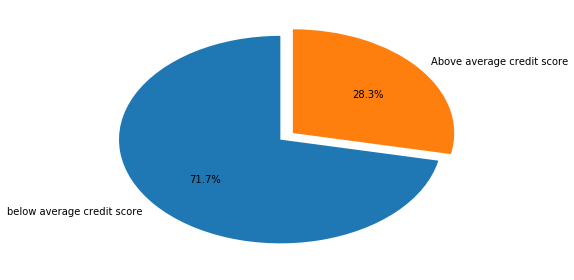

```python
# We query the above average D/I (Debt-to-income) ratio
bad_credit = sum(df1.query("CreditScore < 700")['CreditScore'].value_counts())

# We query the below average D/I (Debt-to-income) ratio
good_credit = sum(df1.query("CreditScore >= 700")['CreditScore'].value_counts())

# we draw a pie chart
sizes = [bad_credit, good_credit]
labels = ['below average credit score', 'Above average credit score']
explode = (0, 0.1)
plt.pie(sizes, labels=labels, autopct='%1.1f%%', startangle=90, explode=explode)
plt.tight_layout()
plt.show()
```

### DebtToIncomeRatio

```python
# What's the statistical distribution?
df1.DebtToIncomeRatio.describe()
```

```
count    7394.000000
mean        0.313922
std         0.757376
min         0.000000
25%         0.140000
50%         0.210000
75%         0.330000
max        10.010000
Name: DebtToIncomeRatio, dtype: float64
```

```python
# What are the outliers boundaries?
q1, q3= np.percentile(df1.DebtToIncomeRatio,[25,75])
iqr = q3 - q1
lower_bound = q1 - (1.5 * q1)
upper_bound = q3 + (1.5 * q3)
print("Outlier Lower Boundary: {}\nOutlier Upper Boundary: {}".format(lower_bound, upper_bound))
```

```
Outlier Lower Boundary: -0.07
Outlier Upper Boundary: 0.825
```

A debt-to-income ratio of 36% is considered reasonable to still qualify for lending products with most financial services companies. So let's look at the percentage of people with collection fees that have a below average debt-to-income ratio.

```python
x = 100*df1.query("DebtToIncomeRatio > 0.36")['DebtToIncomeRatio'].count()/df1.shape[0]
x = round(x, 0)
print("Only {}% of the borrowers having a high collection fees also have a below average debt-to-income ratio.".format(x) )
```

[output not shown]

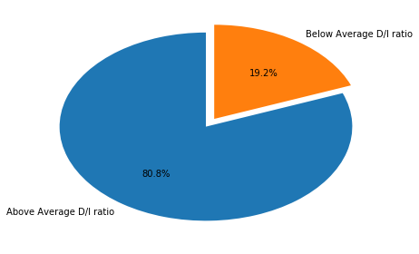

```python
# We query the above average D/I (Debt-to-income) ratio
good_ratio = sum(df1.query("DebtToIncomeRatio <= 0.36")['DebtToIncomeRatio'].value_counts())

# We query the below average D/I (Debt-to-income) ratio
bad_ratio = sum(df1.query("DebtToIncomeRatio > 0.36")['DebtToIncomeRatio'].value_counts())

# we draw a ppie chart
sizes = [good_ratio, bad_ratio]
labels = ['Above Average D/I ratio', 'Below Average D/I ratio']
explode = (0, 0.1)
fig1, ax1 = plt.subplots()
ax1.pie(sizes, labels=labels, autopct='%1.1f%%', startangle=90, explode=explode)
plt.tight_layout()
plt.show()
```

## Bivariate Exploration

### LP_CollectionFees - Occupation

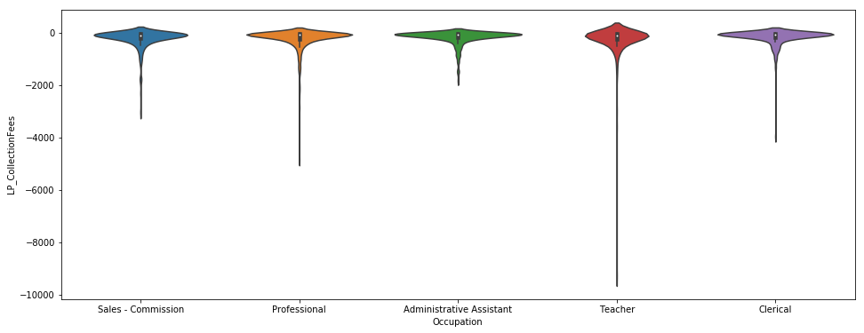

```python
occupation = df1.query("Occupation == ('Professional','Clerical','Teacher','Administrative Assistant','Sales - Commission')")['Occupation']
collection_fees = df1.query("Occupation == ('Professional','Clerical','Teacher','Administrative Assistant','Sales - Commission')")['LP_CollectionFees']
plt.figure(figsize=(16,6))
sb.violinplot(data = df, x = occupation, y = collection_fees)
plt.xticks(rotation=0);
```

The majority of **occupations** have their collection fees around zero and there is significantly fewer observations while we move below zero. The occupation where we observe the highest collection fees are respectively: Teacher, Prefessional, Clerical, Sales-commission, and finally Administrative Assistant.

### LP_CollectionFees - EmploymentStatus

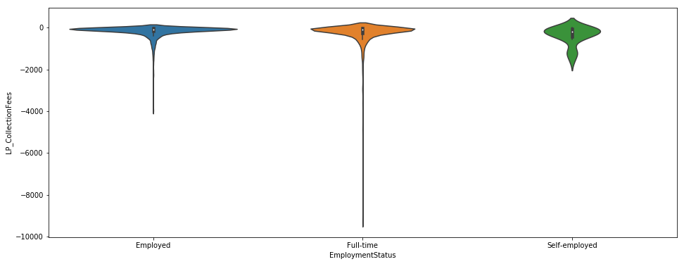

```python
employmentStatus = df1.query("EmploymentStatus == ('Full-time','Employed','Self-employed')")['EmploymentStatus']
plt.figure(figsize=(16,6))
sb.violinplot(data = df, x = employmentStatus, y = collection_fees)
plt.xticks(rotation=0);
```

We can make approximately the same observation as above in terms of the distribution of data with people working full-time prsenting the highest collection fees, followed by people that are employed and finally those that are self-employed.

### LP_CollectionFees - BorrowerState

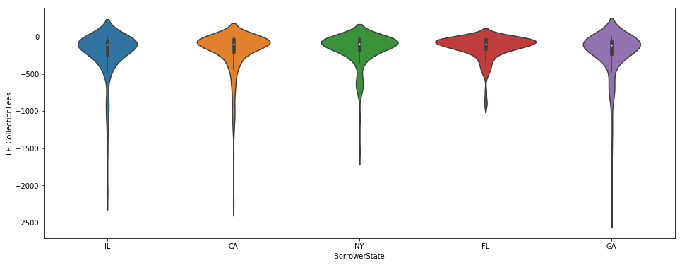

```python
borrowerState = df1.query("BorrowerState == ('CA','IL','GA','NY','FL')")['BorrowerState']
plt.figure(figsize=(16,6))
sb.violinplot(data = df, x = borrowerState, y = collection_fees)
plt.xticks(rotation=0);
```

Here we notice that Georgia has the highest collection fees, followed by California, Illinois, New York and last Florida,

### LP_CollectionFees - CreditScore

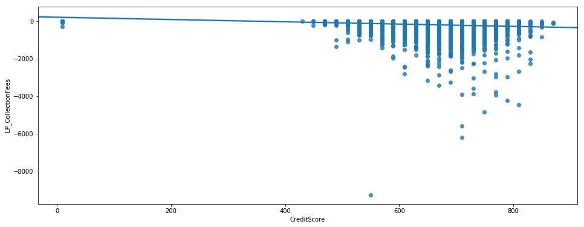

```python
creditScore = df1.CreditScore
collectionFees = df1.LP_CollectionFees
plt.figure(figsize=(16,6))
sb.regplot(x=creditScore, y=collectionFees);
```

### LP_CollectionFees - DebtToIncomeRatio

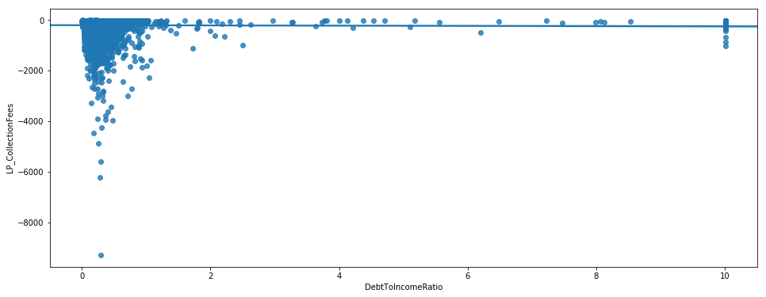

```python
debtToIncome = df1.DebtToIncomeRatio
plt.figure(figsize=(16,6))
sb.regplot(x=debtToIncome, y=collectionFees);
```

As with credit score, here we can see that people with the best debt-to-income ratio are the one with the highest collection fees.

### DebtToIncome - CreditScore

```python
# Group credit score data in bins
bins = list(np.arange(0,1100,350))
grades = ['very bad', 'bad', 'good']
df1['CreditGrade'] = pd.cut(df1.CreditScore, bins, labels=grades);
```

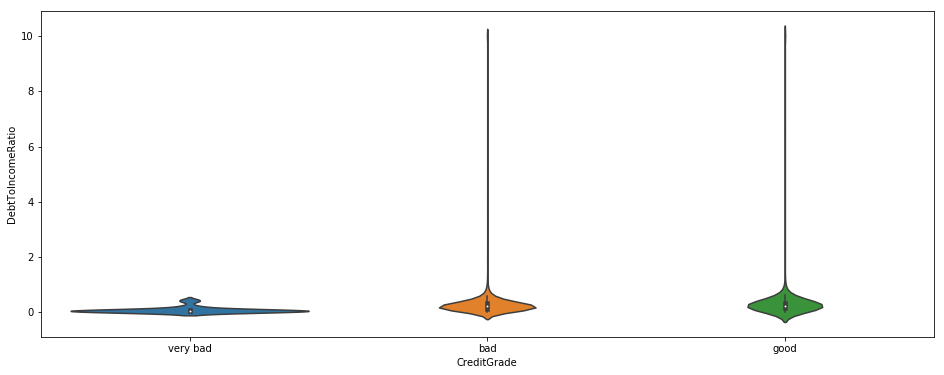

```python
debtToIncome = df1.DebtToIncomeRatio
creditgrade = df1.CreditGrade
plt.figure(figsize=(16,6))
sb.violinplot(data = df1, x = creditgrade, y = debtToIncome)
plt.xticks(rotation=0);
```

People with a very bad credit score have for the majority a debt-to-income ratio around 0 which make sense as they could not qualify for more loans, people with average credit (>350 and <700) and those with a good one (>700) have for the majority a debt-to-income ratio around 0 and 1 and some very few observations having high to very high ratio.

## Multivariate Exploration

### Occupation - LP_CollectionFees - EmploymentStatus

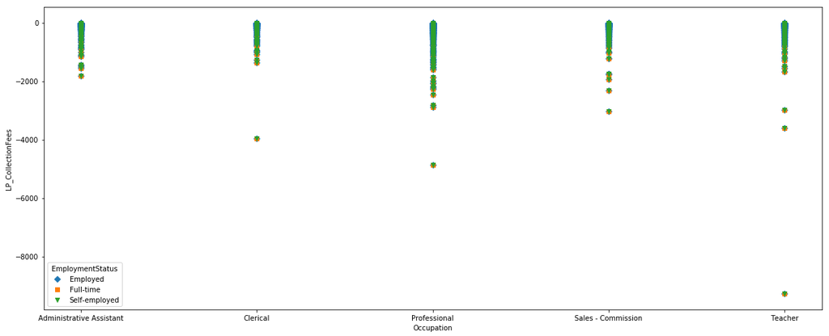

```python
occupation = df1.query("Occupation == ('Professional','Clerical','Teacher','Administrative Assistant','Sales - Commission')")['Occupation']
collection_fees = df1.query("Occupation == ('Professional','Clerical','Teacher','Administrative Assistant','Sales - Commission')")['LP_CollectionFees']
employmentStatus = df1.query("EmploymentStatus == ('Full-time','Employed','Self-employed')")

# We assign a shape to each employment status
status_shape = [['Employed','D'], ['Full-time', 's'], ['Self-employed', 'v']]

plt.figure(figsize=(20,8))

for status, shape in status_shape:
    plt.scatter(data = employmentStatus, x = occupation, y = collection_fees, marker = shape)

plt.legend(['Employed', 'Full-time', 'Self-employed'], title="EmploymentStatus")
plt.xlabel('Occupation')
plt.ylabel('LP_CollectionFees');
```

### Occupation - LP_CollectionFees - CreditScore

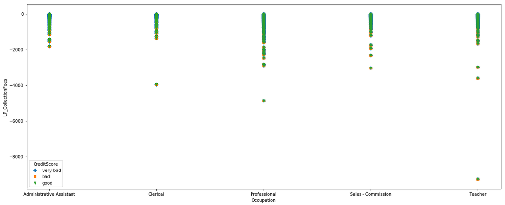

```python
collectionFees = df1.LP_CollectionFees

creditgrade_shape = [['very bad','D'], ['bad', 's'], ['good', 'v']]

plt.figure(figsize=(20,8))

for status, shape in creditgrade_shape:
    plt.scatter(data = creditgrade, x = occupation, y = collection_fees, marker = shape)

plt.legend(['very bad', 'bad', 'good'], title="CreditScore")
plt.xlabel('Occupation')
plt.ylabel('LP_CollectionFees');
```

### Conclusion

> From the two last visualizations, the take away is is that the distribution of the observation doesn't change whether we look at different third variable like **EmploymentStatus** and **CreditScore**, with **Occupation** and **LP_CollectionFees** on the axes. We noticed that overall, borrowers do have below average credit score prior to qualify for a loan. Therefore what we conclude is that bad borrower behaviours seem to be related to a historic of wrong management of bill/debt payment even with sufficiently good financial standing to afford those pyment. We also have so isolated cases of borrowers with above average credit score who fell in the category of high collection fees, the justification is that they have started having this bad behaviour after they got the loan but this still confirm that those collection fees are by the fact that the company has hard time getting the money back from the borrowers because they are just not making their monthly payments even though they could definitely afford them.